# Statistical Inference Notes

Howard J

December 10, 2017

```r
library(UsingR)
library(tidyverse)
library(grid)
library(png)
```

## Distributions

For each distribution, R has four functions:

| Prefix | Continous | Discrete |
| --- | --- | --- |
| d | PDF | PMF |
| p | CDF | CDF |
| q | quantile | quantile |
| r | random | random |

Distribution root name:

| Distribution | Root |
| --- | --- |
| Binomial | binom |
| Poisson | pois |
| Normal | norm |
| t | t |
| F | F |
| Chi-square | chisq |

## Discrete Probability Distribution

### Binomial Distribution

#### Bernoulli and Binomial Random Variables

Suppose that a trial, or an experiment, whose outcome can be classified as either a success or a failure is performed. If we let $X = 1$ when the outcome is a $success$ and $X = 0$ when it is a $failure$, then the PMF of $X$ is given by:
$$p(0) = P\{X = 0\} = 1 - p$$
$$p(1) = P\{X = 1\} = p$$

where $p$, $0 \le p \le 1$, is the probability that the trial is a *success*.

A random variable X is said to be a **Bernoulli random variable** if its PMF is given by the equations above for some $p \in (0, 1)$.

Suppose now that $n$ independent trials, each of which results *in a success with probability $p$* and *in a failure with probability $1 - p$*, are to be performed. *If $X$ represents the number of successes that occur in the $n$ trials, then $X$ is said to be a **Binomial random variable** with parameters $(n, p)$*. Thus, *a Bernoulli random variable is just a binomial random variable with parameters (1, p)*.

The PMF of a binomial random variable having parameters (n, p) is given by:
$$p(x) = {n \choose x} p^x (1-p)^{(n-x)}$$
where $x=0,1,...,n$, notice that $x$ begins at 0. ${n \choose 0}$ is 1.

The **Binomial Random Variables** are obtained as the sum of iid **Bernoulli trials**. So if a Bernoulli trial is the result of a coin flip, a binomial random variable is the total number of heads.

To write it out as mathematics, let $X_1,\ldots, X_n$ be iid Bernoulli $(p)$, then $X = \sum_{i=1}^n X_i$ is a binomial random variable. We write out that $X \sim Binomial(n,p)$. The binomial PMF is

$$P(X = x) =
\left(
\begin{array}{c}
n \\ x
\end{array}
\right)
p^x(1 - p)^{n-x}$$

where $x=0,\ldots, n$. Recall that the notation

$$\left(
\begin{array}{c} n \\ x \end{array}
\right) = \frac{n!}{x!(n-x)!}$$

*Note:* $n \choose x$ counts the number of ways of selecting $x$ items out of $n$ *without replacement disregarding the order* of the items.

*Example:* Suppose a friend has 8 children, $7$ of which are girls and none are twins. If each gender has an independent $50%$ probability for each birth, what’s the probability of getting $7$ or more girls out of $8$ births?

```r
choose(8, 7) * 0.5^8 + choose(8, 8) * 0.5^8
```

```
## [1] 0.03515625
```

```r
pbinom(6, size = 8, prob = 0.5, lower.tail = FALSE)
```

```
## [1] 0.03515625
```

*Notice:* for `lower.tail` argument, if TRUE, probabilities are $P[X \le x]$, corresponding to CDF; if FALSE, $P[X \gt x]$, corresponding to survival function.

#### Binomial Distribution

The **Binomial Distribution** model deals with finding the *probability of success of an event which has only two possible outcomes in a series of experiments*. For example, tossing of a coin always gives a head or a tail. The probability of finding exactly 3 heads in tossing a coin repeatedly for 10 times is estimated during the binomial distribution.

Four functions are provided by R:  
`dbinom(x, size, prob)`  
`pbinom(q, size, prob)`  
`qbinom(p, size, prob)`  
`rbinom(n, size, prob)`

`x, q`: vector of quantiles (input vector of integers), e.g. number of heads.  
`p` is a vector of probabilities.  
`n` is number of observations.  
`size` is the number of trials.  
`prob` is the probability of success of each trial, e.g. the probability for head of each trial.

**dbinom**  
`dbinom` returns binomial probabilities. The returned value is PMF values at the input vector of integers.

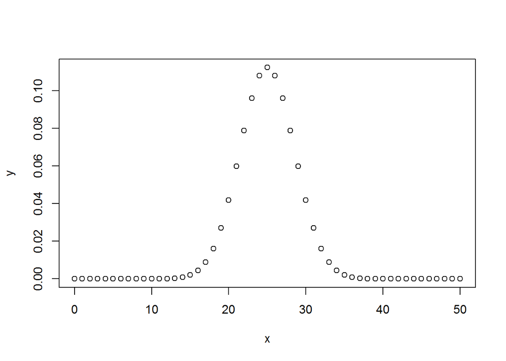

```r
# Create a sample of 50 numbers which are incremented by 1.
x <- seq(0,50,by = 1)
# Create the binomial distribution.
y <- dbinom(x,50,0.5)
plot(x,y)
```

**pbinom**  
`pbinom(x, size, prob)` gives the cumulative probability distribution of an event. It is a single value representing the cumulative probability.  
*Example:* Probability of getting 26 or less heads from a 51 tosses of a coin.

```r
x <- pbinom(26,51,0.5)
print(x)
```

```
## [1] 0.610116
```

*Example:* the cumulative probability distribution for the previous example.

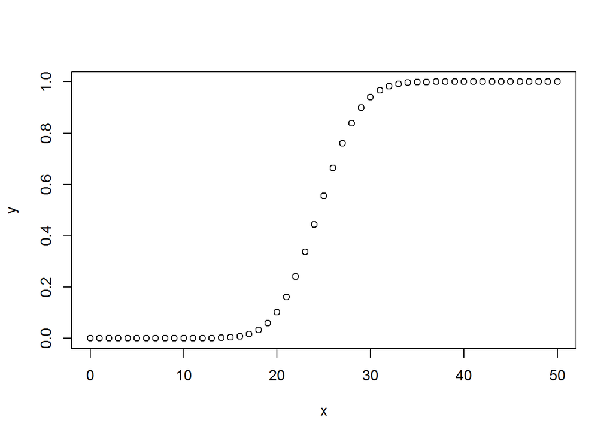

```r
x <- seq(0,50,by = 1)
y <- pbinom(x,50,0.5)
plot(x,y)
```

**qbinom**  
`qbinom` takes the cumulative probability value and gives a number which matches this cumulative probability value.  
*Example:* how many heads or less will have a probability of success of 0.25 when a coin is tossed 51 times:

```r
x <- qbinom(0.25,51,1/2)
print(x)
```

```
## [1] 23
```

**rbinom**  
`rbinom` generates required number of random values of given probability from a given sample.  
*Example:* generate 8 random values (each value is the number of success, e.g. heads) from a sample of 150 with probability of 0.4:

```r
x <- rbinom(8,150,.4)
print(x)
```

```
## [1] 56 64 66 66 57 56 55 58
```

### The Normal Distribution

In fact, the normal distribution only requires two numbers to characterize it. Specifically, a random variable is said to follow a **Normal Distribution** or **Gaussian Distribution** with *mea*n $\mu$ and *variance* $\sigma^2$ if the associated density is:
$$(2\pi \sigma^2)^{-1/2}e^{-(x - \mu)^2/2\sigma^2}.$$

If $X$ is a random variable with this density, then $E[X] = \mu$ and $Var(X) = \sigma^2$, $X$ is denoted as a **Normal Random Variable**. We write as $X\sim N(\mu, \sigma^2)$. When $\mu = 0$ and $\sigma = 1$ the resulting distribution is called **Standard Normal Distribution**. **Standard normal Random Variable** are often labeled $Z$.

If we know that the *population is normally distributed*, we can estimate about the population, by estimating the population mean and variance. (These two population quantities are estimated by the sample mean and the sample variance.)

### Shifting and Scaling Normal Distribution

Since the normal distribution is characterized by only the *mean* and *variance*, which are a *shift* and a *scale*, we can transform normal random variables to be standard normals and vice versa. The normal distribution $X \sim N(\mu,\sigma^2)$ can be converted to standard normal distribution:
$$Z = \frac{X -\mu}{\sigma} \sim N(0, 1^2)$$

Therefore, normal distribution $X$ can be written as a standard normal times the scale and then plus the shift:
$$X = \mu + \sigma Z \sim N(\mu, \sigma^2)$$

Where $X$ is $X \sim N(\mu,\sigma^2)$.

We can use these facts to answer questions about non-standard normals by relating them back to the standard normal.